# Clastering

Michał Żychowski

2023-05-24

## Przygotowanie danych

Zacznijmy od zaimportowania naszej bazy danych oraz niezbędnych bibliotek.

```r
library(readxl)
dane <- read_excel("dane.xlsx")
head(dane)
```

```
## # A tibble: 6 × 6
##   Województwo        `Użytki rolne` `Grunty leśne` Przemysł pe…¹ Budow…² Hande…³
##   <chr>                       <dbl>          <dbl>         <dbl>   <dbl>   <dbl>
## 1 Dolnośląskie                 918.           613.         66355    6889   22390
## 2 Kujawsko-pomorskie          1058.           431.         40225    6355   14955
## 3 Lubelskie                   1384.           597.         25039    5382   15818
## 4 Lubuskie                     444.           711.         48185    5262   18427
## 5 Łódzkie                      982.           397.         45487    5341   19767
## 6 Małopolskie                  557.           439.         42745    7304   21646
## # … with abbreviated variable names ¹`Przemysł per capita`,
## #   ²`Budowa per capita`, ³`Handel per capita`
```

```r
library(lmtest)
library(cluster)
library(fpc)
library(MASS)
```

Generujemy ramkę danych i przypisujemy liczbę kolumn do zmiennej.

```r
Frame1 <- data.frame(dane)
K <- ncol(Frame1)
```

Standaryzujemy wartości zmiennych - standaryzacja Gaussa

```r
Frame2 <- data.frame(scale(Frame1[,2:K]))
```

Generujemy ramkę z przeskalowanymi danymi

```r
X <- data.frame(Frame1[1],Frame2)
head(X)
```

```
##          Województwo Użytki.rolne Grunty.leśne Przemysł.per.capita
## 1       Dolnośląskie   -0.0364377   0.11183418        1.4097728212
## 2 Kujawsko-pomorskie    0.2622311  -0.84706544       -0.3547486728
## 3          Lubelskie    0.9590536   0.02672787       -1.3802375136
## 4           Lubuskie   -1.0499005   0.63145840        0.1827787322
## 5            Łódzkie    0.1002739  -1.02837888        0.0005866544
## 6        Małopolskie   -0.8087832  -0.80794826       -0.1845766803
##   Budowa.per.capita Handel.per.capita
## 1         0.5595595       0.054123609
## 2         0.1065676      -0.496980091
## 3        -0.7188278      -0.433012035
## 4        -0.8206237      -0.239625411
## 5        -0.7536081      -0.140300736
## 6         0.9116038      -0.001023822
```

## Grupowanie danych

Do przeprowadzenia klasteryzacji konieczne jest stworzenie macierzy odległości, przy czym wybieramy metodę euklidesową.

```r
dist.X <- dist(X[2:K],method = "euclidian")
round(dist.X,2)
```

```
##       1    2    3    4    5    6    7    8    9   10   11   12   13   14   15
## 2  2.15
## 3  3.26 1.73
## 4  2.19 2.26 2.63
## 5  2.25 1.03 1.96 2.03
## 6  2.03 1.44 2.85 2.31 1.92
## 7  3.46 4.74 5.05 5.01 4.89 4.80
## 8  2.84 1.57 2.90 2.52 1.43 1.74 5.91
## 9  3.03 2.15 1.90 1.23 2.09 2.55 5.62 2.53
## 10 2.36 1.19 1.19 2.02 1.78 1.90 4.51 2.52 1.66
## 11 1.72 2.52 3.52 2.85 3.14 1.82 3.74 3.38 3.34 2.36
## 12 1.91 2.22 3.53 1.96 1.80 2.03 5.19 1.66 2.74 2.89 3.02
## 13 3.47 1.97 2.46 2.33 1.58 2.46 6.35 1.27 1.89 2.49 4.02 2.34
## 14 3.36 2.49 1.42 2.00 2.46 3.31 5.34 3.34 1.23 1.72 3.76 3.53 2.68
## 15 3.45 4.46 4.62 4.60 4.44 4.50 1.34 5.54 5.16 4.20 3.82 4.90 5.82 4.92
## 16 2.49 2.37 2.41 2.32 2.98 2.36 4.26 3.52 2.27 1.41 1.80 3.50 3.60 2.36 4.13
```

Obecnie przeprowadzamy analizę naszych klastrów przy użyciu metody ward.D2 oraz generujemy wykres.

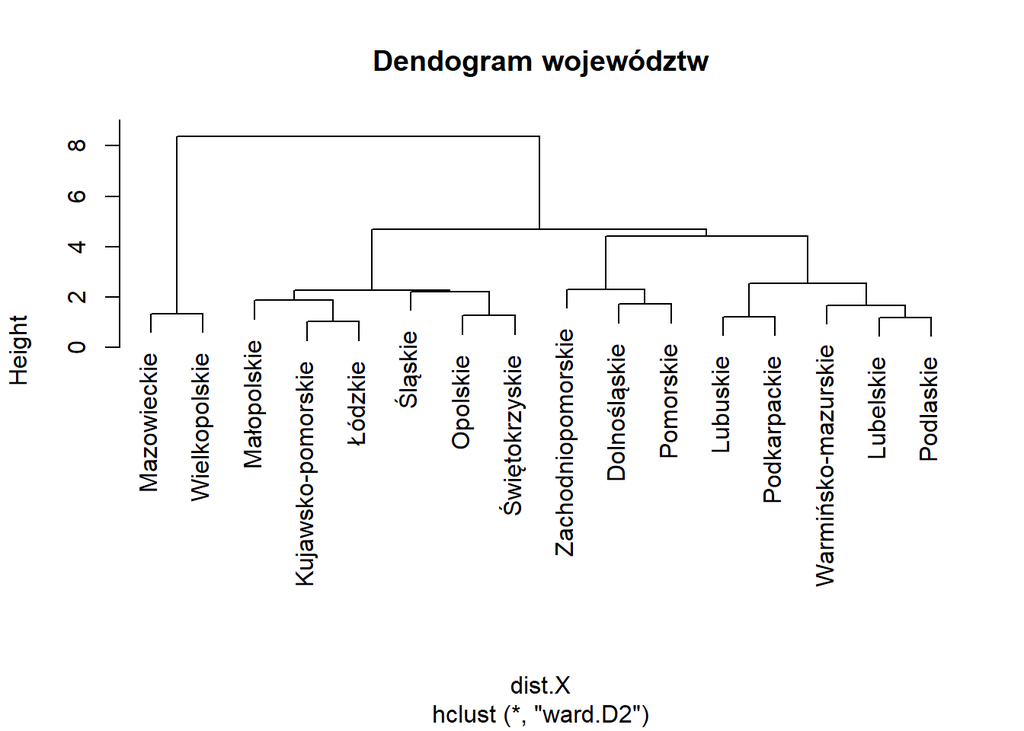

```r
CW<-hclust(dist.X,method = "ward.D2",members = NULL)

A1<-plot(CW,labels = X[,1],main="Dendogram województw")
```

## Tworzenie klastrów

Po analizie powyższego wykresu, można wywniskować, że najelpsze będzie podzielenie naszych danych na 3 lub 4 klastry. Aby tego dokonać, możemy skorzystać z poniższej komendy.

```r
#dla 3 klastrów
clust3<-cutree(CW,k=3)
#dla 4 klastrów
clust4<-cutree(CW,k=4)
```

Możemy zobaczyć przypisanie poszczególnych województw do odpowiednich klastrów.

Dla 3 klastrów

```r
showc3 <- lapply(1:3,function(which.group)Frame1[1][clust3==which.group,])
showc3
```

```
## [[1]]
## [1] "Dolnośląskie"        "Lubelskie"           "Lubuskie"
## [4] "Podkarpackie"        "Podlaskie"           "Pomorskie"
## [7] "Warmińsko-mazurskie" "Zachodniopomorskie"
##
## [[2]]
## [1] "Kujawsko-pomorskie" "Łódzkie"            "Małopolskie"
## [4] "Opolskie"           "Śląskie"            "Świętokrzyskie"
##
## [[3]]
## [1] "Mazowieckie"   "Wielkopolskie"
```

Dla 4 klastórw

```r
showc4 <- lapply(1:4,function(which.group)Frame1[1][clust4==which.group,])
showc4
```

```
## [[1]]
## [1] "Dolnośląskie"       "Pomorskie"          "Zachodniopomorskie"
##
## [[2]]
## [1] "Kujawsko-pomorskie" "Łódzkie"            "Małopolskie"
## [4] "Opolskie"           "Śląskie"            "Świętokrzyskie"
##
## [[3]]
## [1] "Lubelskie"           "Lubuskie"            "Podkarpackie"
## [4] "Podlaskie"           "Warmińsko-mazurskie"
##
## [[4]]
## [1] "Mazowieckie"   "Wielkopolskie"
```

## Porównanie klastrów

Dla naszych klastórw możemy zobaczyć klika następujących parametrów

### Dla 3 klastrów

Rozmiar

```r
S3<-cluster.stats(dist.X,clust3)
S3$cluster.size
```

```
## [1] 8 6 2
```

Zróżnicowanie wewnątrzgrupowe

```r
S3$average.distance
```

```
## [1] 2.279293 1.763464 1.344013
```

Macierz separacji

```r
S3$separation.matrix
```

```
##          [,1]     [,2]     [,3]
## [1,] 0.000000 1.190555 3.453571
## [2,] 1.190555 0.000000 4.437966
## [3,] 3.453571 4.437966 0.000000
```

Średni dystans pomiędzy grupami

```r
S3$average.between
```

```
## [1] 3.390526
```

Średni dystans wewnątrz grup

```r
S3$average.within
```

```
## [1] 1.968947
```

### Dla 4 klastrów

Rozmiar

```r
S4<-cluster.stats(dist.X,clust4)
S4$cluster.size
```

```
## [1] 3 6 5 2
```

Zróżnicowanie wewnątrzgrupowe

```r
S4$average.distance
```

```
## [1] 2.005605 1.763464 1.699207 1.344013
```

Macierz separacji

```r
S4$separation.matrix
```

```
##          [,1]     [,2]     [,3]     [,4]
## [1,] 0.000000 1.821148 1.412754 3.453571
## [2,] 1.821148 0.000000 1.190555 4.437966
## [3,] 1.412754 1.190555 0.000000 4.196570
## [4,] 3.453571 4.437966 4.196570 0.000000
```

Średni dystans pomiędzy grupami

```r
S4$average.between
```

```
## [1] 3.280124
```

Średni dystans wewnątrz grup

```r
S4$average.within
```

```
## [1] 1.736354
```

### Wybór lepszego

Dla oceny, który podział na klastry jest lepszy, istnieje możliwość sprawdzenia trzech rzeczy: Stosunek między średnią grupową a różnicami pozagrupowymi

```r
ifelse(S3$wb.ratio<=S4$wb.ratio,"Klastorwanie pierwsze jest lepsze","Klastorwanie drugie jest lepsze")
```

```
## [1] "Klastorwanie drugie jest lepsze"
```

Współczynnik gamma

```r
ifelse(S3$pearsongamma>=S4$pearsongamma,"Klastorwanie pierwsze jest lepsze","Klastorwanie drugie jest lepsze")
```

```
## [1] "Klastorwanie drugie jest lepsze"
```

Indeks Dunna

```r
ifelse(S3$dunn2>=S4$dunn2,"Klastorwanie pierwsze jest lepsze","Klastorwanie drugie jest lepsze")
```

```
## [1] "Klastorwanie drugie jest lepsze"
```

### Podsumowanie

Podsumowując podział na 4 klastry jest lepszy.